# TIPS DATASET

```python
import pandas as pd
import numpy as np
import matplotlib.pyplot as plt
import seaborn as sns
from sklearn import preprocessing
from sklearn.preprocessing import LabelEncoder
from sklearn.preprocessing import MinMaxScaler
from sklearn.preprocessing import StandardScaler
```

```python
df = pd.read_csv('Downloads/tips.csv')
```

```python
df
```

|  | total_bill | tip | sex | smoker | day | time | size |
| --- | --- | --- | --- | --- | --- | --- | --- |
| 0 | 16.99 | 1.01 | Female | No | Sun | Dinner | 2 |
| 1 | 10.34 | 1.66 | Male | No | Sun | Dinner | 3 |
| 2 | 21.01 | 3.50 | Male | No | Sun | Dinner | 3 |
| 3 | 23.68 | 3.31 | Male | No | Sun | Dinner | 2 |
| 4 | 24.59 | 3.61 | Female | No | Sun | Dinner | 4 |
| ... | ... | ... | ... | ... | ... | ... | ... |
| 239 | 29.03 | 5.92 | Male | No | Sat | Dinner | 3 |
| 240 | 27.18 | 2.00 | Female | Yes | Sat | Dinner | 2 |
| 241 | 22.67 | 2.00 | Male | Yes | Sat | Dinner | 2 |
| 242 | 17.82 | 1.75 | Male | No | Sat | Dinner | 2 |
| 243 | 18.78 | 3.00 | Female | No | Thur | Dinner | 2 |

244 rows × 7 columns

## 1. What are the first few rows of the dataset?

```python
df.head()
```

|  | total_bill | tip | sex | smoker | day | time | size |
| --- | --- | --- | --- | --- | --- | --- | --- |
| 0 | 16.99 | 1.01 | Female | No | Sun | Dinner | 2 |
| 1 | 10.34 | 1.66 | Male | No | Sun | Dinner | 3 |
| 2 | 21.01 | 3.50 | Male | No | Sun | Dinner | 3 |
| 3 | 23.68 | 3.31 | Male | No | Sun | Dinner | 2 |
| 4 | 24.59 | 3.61 | Female | No | Sun | Dinner | 4 |

## 2. How many records are there in the dataset?

```python
df.shape
```

```
(244, 7)
```

## 3. What are the data types of each column?

```python
df.dtypes
```

```
total_bill    float64
tip           float64
sex            object
smoker         object
day            object
time           object
size            int64
dtype: object
```

## 4. Are there any missing values in the dataset?

```python
df.isnull().sum()
```

```
total_bill    0
tip           0
sex           0
smoker        0
day           0
time          0
size          0
dtype: int64
```

## 5. What is the distribution of total bill amounts?

```python
df['total_bill'].value_counts()
```

```
13.42    3
13.81    2
15.98    2
17.92    2
10.07    2
        ..
24.71    1
21.16    1
28.97    1
22.49    1
18.78    1
Name: total_bill, Length: 229, dtype: int64
```

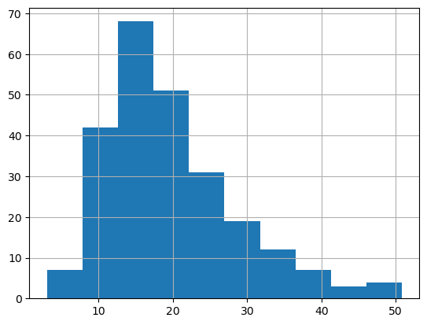

```python
df['total_bill'].hist()
```

## 7. What is the relationship between total bill and tip amount?

```python
df[['total_bill','tip']].corr()
```

|  | total_bill | tip |
| --- | --- | --- |
| total_bill | 1.000000 | 0.675734 |
| tip | 0.675734 | 1.000000 |

## 8. How does the day of the week affect the total bill?

```python
df.groupby(df['day'])['total_bill'].mean()
```

```
day
Fri     17.151579
Sat     20.441379
Sun     21.410000
Thur    17.682742
Name: total_bill, dtype: float64
```

## 9. Is there a difference in tipping behavior between smokers and non-smokers?

```python
df.groupby('smoker')['tip'].mean()
```

```
smoker
No     2.991854
Yes    3.008710
Name: tip, dtype: float64
```

## 10. How can we encode categorical variables like "sex" and "time"?

```python
label_encoder = LabelEncoder()

columns_to_encode = ['sex','time']
for column in columns_to_encode:
    df[column] = label_encoder.fit_transform(df[column])

print(df)
```

```
     total_bill   tip  sex smoker   day  time  size
0         16.99  1.01    0     No   Sun     0     2
1         10.34  1.66    1     No   Sun     0     3
2         21.01  3.50    1     No   Sun     0     3
3         23.68  3.31    1     No   Sun     0     2
4         24.59  3.61    0     No   Sun     0     4
..          ...   ...  ...    ...   ...   ...   ...
239       29.03  5.92    1     No   Sat     0     3
240       27.18  2.00    0    Yes   Sat     0     2
241       22.67  2.00    1    Yes   Sat     0     2
242       17.82  1.75    1     No   Sat     0     2
243       18.78  3.00    0     No  Thur     0     2

[244 rows x 7 columns]
```

## 11. Should we scale or standardize the numerical features?

```python
scaler = StandardScaler()
```

```python
columns_to_standardize = ['total_bill', 'tip', 'sex','time','size']
```

```python
df[columns_to_standardize] = scaler.fit_transform(df[columns_to_standardize])
```

## 12. How can we create dummy variables for day and time?

```python
import pandas as pd

day_dummies = pd.get_dummies(df["day"], prefix="day")


time_dummies = pd.get_dummies(df["time"], prefix="time")

df = pd.concat([df, day_dummies, time_dummies], axis=1)

df = df.drop(["day", "time"], axis=1)

print(df)
```

```
     total_bill       tip       sex smoker      size  day_Fri  day_Sat  \
0     -0.314711 -1.439947 -1.343353     No -0.600193        0        0
1     -1.063235 -0.969205  0.744406     No  0.453383        0        0
2      0.137780  0.363356  0.744406     No  0.453383        0        0
3      0.438315  0.225754  0.744406     No -0.600193        0        0
4      0.540745  0.443020 -1.343353     No  1.506958        0        0
..          ...       ...       ...    ...       ...      ...      ...
239    1.040511  2.115963  0.744406     No  0.453383        0        1
240    0.832275 -0.722971 -1.343353    Yes -0.600193        0        1
241    0.324630 -0.722971  0.744406    Yes -0.600193        0        1
242   -0.221287 -0.904026  0.744406     No -0.600193        0        1
243   -0.113229  0.001247 -1.343353     No -0.600193        0        0

     day_Sun  day_Thur  time_-0.6215815605080609  time_1.6087993330796873
0          1         0                         1                        0
1          1         0                         1                        0
2          1         0                         1                        0
3          1         0                         1                        0
4          1         0                         1                        0
..       ...       ...                       ...                      ...
239        0         0                         1                        0
240        0         0                         1                        0
241        0         0                         1                        0
242        0         0                         1                        0
243        0         1                         1                        0

[244 rows x 11 columns]
```

## 13. Can we predict the tip amount based on the total bill using linear regression?

```python
from sklearn.model_selection import train_test_split
from sklearn.linear_model import LinearRegression
from sklearn.metrics import mean_squared_error, r2_score
```

```python
X = df[['total_bill']]
y = df['tip']

X_train, X_test, y_train, y_test = train_test_split(X, y, test_size=0.2, random_state=42)
```

```python
model = LinearRegression()

model.fit(X_train, y_train)
```

```
LinearRegression()
```

```python
y_pred = model.predict(X_test)
```

```python
mse = mean_squared_error(y_test, y_pred)
r2 = r2_score(y_test, y_pred)

print(f"Mean Squared Error: {mse:.2f}")
print(f"R-squared: {r2:.2f}")
```

```
Mean Squared Error: 0.30
R-squared: 0.54
```

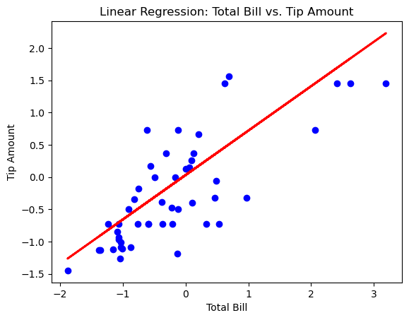

```python
import matplotlib.pyplot as plt

plt.scatter(X_test, y_test, color='blue')
plt.plot(X_test, y_pred, color='red', linewidth=2)
plt.xlabel('Total Bill')
plt.ylabel('Tip Amount')
plt.title('Linear Regression: Total Bill vs. Tip Amount')
plt.show()
```

## 14. What features should we include in the model?

```python
## we use sex feature
## we use smoker feature
## we use day time size
```

## 15. How do we split the data into training and testing sets?

```python
from sklearn.model_selection import train_test_split
```

```python
x = df.drop('smoker', axis=1)
y = df['smoker']
```

```python
x_train,x_test,y_train,y_test=train_test_split(x,y,test_size=0.25,random_state=42)
```

## 16. How well does the linear regression model perform in predicting tip amounts?

The performance of a linear regression model in predicting tip amounts depends on several factors, including the quality of the data, the choice of features, and the underlying relationships within the dataset. Linear regression is a straightforward and interpretable model commonly used for predicting numerical outcomes like tip amounts. Here are some considerations for assessing the performance of a linear regression model in predicting tip amounts:

### Data Quality:

The quality and cleanliness of the dataset are crucial. Ensure that the data is free from errors, outliers, and missing values. Check for multicollinearity (high correlations between predictor variables), as it can affect the stability of coefficient estimates.

### Feature Selection:

Carefully select relevant features (predictors) that are likely to have a linear relationship with tip amounts. Common features might include the total bill amount, number of diners, meal type, and service quality. Feature engineering can improve model performance. For example, you might create new features like tip percentage (tip amount divided by the total bill) or categorical variables for meal type.

### Assumption Checking:

Linear regression assumes that the relationship between predictors and the target variable is linear. You should check this assumption by examining scatterplots and residual plots. Assess whether the residuals (the differences between actual and predicted tip amounts) are normally distributed and homoscedastic (constant variance).

### Model Evaluation:

Use appropriate evaluation metrics to assess model performance, such as Mean Absolute Error (MAE), Mean Squared Error (MSE), and Root Mean Squared Error (RMSE). R-squared (R²) can provide insight into the proportion of variance explained by the model. A higher R² indicates a better fit to the data.

### Cross-Validation:

Employ cross-validation techniques (e.g., k-fold cross-validation) to evaluate the model's generalization performance and to ensure that it doesn't overfit to the training data.

### Outlier Detection and Handling:

Identify and handle outliers in the dataset, as extreme values can significantly affect the linear regression model. Consider robust regression techniques if outliers are a concern.

### Feature Scaling:

Scaling or normalizing features can improve model convergence and stability, especially when predictor variables have different scales.

### Regularization:

If needed, apply regularization techniques like Ridge or Lasso regression to prevent overfitting and improve model robustness. Interpretability:

Linear regression provides interpretable coefficients, allowing you to understand the impact of each predictor on tip amounts. This can be valuable for explaining model predictions.

### Comparison with Other Models:

Depending on the data and the complexity of the relationships, other regression models, such as polynomial regression or tree-based models like Random Forest, may perform better than linear regression.

### Business Context:

Consider the practical implications of model predictions in a real-world context. Ensure that the model's predictions align with the goals and expectations of the problem at hand.

## 17. What is the mean squared error of the model?

```python
for col in df.select_dtypes(include=['object']).columns:

    print(f"{col}:{df[col].unique()}")
```

```
smoker:['No' 'Yes']
```

```python
for col in df.select_dtypes(include=['object']).columns:

    label_encoder=preprocessing.LabelEncoder()
    label_encoder.fit(df[col].unique())

    df[col]=label_encoder.transform(df[col])

    print(f"(col):{df[col].unique()}")
```

```
(col):[0 1]
```

```python
x = df.drop('smoker', axis=1)
y = df['smoker']
```

```python
x_train,x_test,y_train,y_test=train_test_split(x,y,test_size=0.25,random_state=42)
```

```python
model = LinearRegression()

model.fit(x_train, y_train)
```

```
LinearRegression()
```

```python
y_pred = model.predict(x_test)
```

```python
from sklearn.metrics import mean_squared_error

mse = mean_squared_error(y_test, y_pred)

print(f"Mean Squared Error (MSE): {mse:.2f}")
```

```
Mean Squared Error (MSE): 0.21
```

## 18. What is the coefficient of determination (R-squared) of the model?

```python
from sklearn.metrics import r2_score

r2 = r2_score(y_test, y_pred)

print(f"R-squared (R2) Score: {r2:.2f}")
```

```
R-squared (R2) Score: 0.09
```

## 19. Can we build a regression model to predict total bill based on other features?

```python
X = df.drop('total_bill', axis=1)
Y = df['total_bill']
```

```python
X_train,X_test,Y_train,Y_test=train_test_split(X,Y,test_size=0.25,random_state=42)
```

```python
model = LinearRegression()

model.fit(X_train, Y_train)
```

```
LinearRegression()
```

```python
y_pred = model.predict(X_test)
```

```python
from sklearn.metrics import mean_squared_error, mean_absolute_error, r2_score

mse = mean_squared_error(y_test, y_pred)

rmse = np.sqrt(mse)

mae = mean_absolute_error(y_test, y_pred)

r2 = r2_score(y_test, y_pred)

print(f"Mean Squared Error (MSE): {mse:.2f}")
print(f"Root Mean Squared Error (RMSE): {rmse:.2f}")
print(f"Mean Absolute Error (MAE): {mae:.2f}")
print(f"R-squared (R2) Score: {r2:.2f}")
```

```
Mean Squared Error (MSE): 0.70
Root Mean Squared Error (RMSE): 0.84
Mean Absolute Error (MAE): 0.69
R-squared (R2) Score: -2.04
```

# TITANIC DATASET

```python
import pandas as pd
import numpy as np
import matplotlib.pyplot as plt
import seaborn as sns
from sklearn.preprocessing import LabelEncoder
```

```python
df = pd.read_csv('Downloads/titanic_train.csv')
```

```python
df
```

|  | PassengerId | Survived | Pclass | Name | Sex | Age | SibSp | Parch | Ticket | Fare | Cabin | Embarked |
| --- | --- | --- | --- | --- | --- | --- | --- | --- | --- | --- | --- | --- |
| 0 | 1 | 0 | 3 | Braund, Mr. Owen Harris | male | 22.0 | 1 | 0 | A/5 21171 | 7.2500 | NaN | S |
| 1 | 2 | 1 | 1 | Cumings, Mrs. John Bradley (Florence Briggs Th... | female | 38.0 | 1 | 0 | PC 17599 | 71.2833 | C85 | C |
| 2 | 3 | 1 | 3 | Heikkinen, Miss. Laina | female | 26.0 | 0 | 0 | STON/O2. 3101282 | 7.9250 | NaN | S |
| 3 | 4 | 1 | 1 | Futrelle, Mrs. Jacques Heath (Lily May Peel) | female | 35.0 | 1 | 0 | 113803 | 53.1000 | C123 | S |
| 4 | 5 | 0 | 3 | Allen, Mr. William Henry | male | 35.0 | 0 | 0 | 373450 | 8.0500 | NaN | S |
| ... | ... | ... | ... | ... | ... | ... | ... | ... | ... | ... | ... | ... |
| 886 | 887 | 0 | 2 | Montvila, Rev. Juozas | male | 27.0 | 0 | 0 | 211536 | 13.0000 | NaN | S |
| 887 | 888 | 1 | 1 | Graham, Miss. Margaret Edith | female | 19.0 | 0 | 0 | 112053 | 30.0000 | B42 | S |
| 888 | 889 | 0 | 3 | Johnston, Miss. Catherine Helen "Carrie" | female | NaN | 1 | 2 | W./C. 6607 | 23.4500 | NaN | S |
| 889 | 890 | 1 | 1 | Behr, Mr. Karl Howell | male | 26.0 | 0 | 0 | 111369 | 30.0000 | C148 | C |
| 890 | 891 | 0 | 3 | Dooley, Mr. Patrick | male | 32.0 | 0 | 0 | 370376 | 7.7500 | NaN | Q |

891 rows × 12 columns

## 1. How many passengers were on the Titanic, and how many survived?

```python
df['Survived'].value_counts()
```

```
0    549
1    342
Name: Survived, dtype: int64
```

## 2. What is the age distribution of passengers on the Titanic?

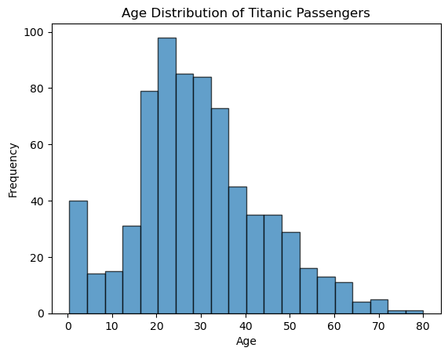

```python
plt.hist(df['Age'], bins=20, edgecolor='k', alpha=0.7)
plt.xlabel('Age')
plt.ylabel('Frequency')
plt.title('Age Distribution of Titanic Passengers')
plt.show()
```

## 3. How does the passenger class (Pclass) relate to survival rates?

```python
survival_rates = df.groupby('Pclass')['Survived'].mean()
```

```python
survival_rates
```

```
Pclass
1    0.629630
2    0.472826
3    0.242363
Name: Survived, dtype: float64
```

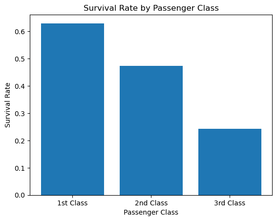

```python
plt.bar(survival_rates.index, survival_rates.values)
plt.xlabel('Passenger Class')
plt.ylabel('Survival Rate')
plt.title('Survival Rate by Passenger Class')
plt.xticks([1, 2, 3], ['1st Class', '2nd Class', '3rd Class'])
plt.show()
```

## 4. Are there any correlations between features (e.g., age and fare)?

```python
df.corr()
```

|  | PassengerId | Survived | Pclass | Age | SibSp | Parch | Fare |
| --- | --- | --- | --- | --- | --- | --- | --- |
| PassengerId | 1.000000 | -0.005007 | -0.035144 | 0.036847 | -0.057527 | -0.001652 | 0.012658 |
| Survived | -0.005007 | 1.000000 | -0.338481 | -0.077221 | -0.035322 | 0.081629 | 0.257307 |
| Pclass | -0.035144 | -0.338481 | 1.000000 | -0.369226 | 0.083081 | 0.018443 | -0.549500 |
| Age | 0.036847 | -0.077221 | -0.369226 | 1.000000 | -0.308247 | -0.189119 | 0.096067 |
| SibSp | -0.057527 | -0.035322 | 0.083081 | -0.308247 | 1.000000 | 0.414838 | 0.159651 |
| Parch | -0.001652 | 0.081629 | 0.018443 | -0.189119 | 0.414838 | 1.000000 | 0.216225 |
| Fare | 0.012658 | 0.257307 | -0.549500 | 0.096067 | 0.159651 | 0.216225 | 1.000000 |

## 5. How can we handle missing values in the dataset (e.g., age, cabin)?

```python
df.isnull().sum()
```

```
PassengerId      0
Survived         0
Pclass           0
Name             0
Sex              0
Age            177
SibSp            0
Parch            0
Ticket           0
Fare             0
Cabin          687
Embarked         2
dtype: int64
```

```python
df['Age'].fillna(df.groupby(['Pclass', 'Sex'])['Age'].transform('mean'), inplace=True)
```

```python
df.isnull().sum()
```

```
PassengerId      0
Survived         0
Pclass           0
Name             0
Sex              0
Age              0
SibSp            0
Parch            0
Ticket           0
Fare             0
Cabin          687
Embarked         2
dtype: int64
```

## 6. Can we create new features (e.g., family size) that might improve prediction?

```python
df['FamilySize'] = df['SibSp'] + df['Parch']
```

```python
df
```

|  | PassengerId | Survived | Pclass | Name | Sex | Age | SibSp | Parch | Ticket | Fare | Cabin | Embarked | FamilySize |
| --- | --- | --- | --- | --- | --- | --- | --- | --- | --- | --- | --- | --- | --- |
| 0 | 1 | 0 | 3 | Braund, Mr. Owen Harris | male | 22.00 | 1 | 0 | A/5 21171 | 7.2500 | NaN | S | 1 |
| 1 | 2 | 1 | 1 | Cumings, Mrs. John Bradley (Florence Briggs Th... | female | 38.00 | 1 | 0 | PC 17599 | 71.2833 | C85 | C | 1 |
| 2 | 3 | 1 | 3 | Heikkinen, Miss. Laina | female | 26.00 | 0 | 0 | STON/O2. 3101282 | 7.9250 | NaN | S | 0 |
| 3 | 4 | 1 | 1 | Futrelle, Mrs. Jacques Heath (Lily May Peel) | female | 35.00 | 1 | 0 | 113803 | 53.1000 | C123 | S | 1 |
| 4 | 5 | 0 | 3 | Allen, Mr. William Henry | male | 35.00 | 0 | 0 | 373450 | 8.0500 | NaN | S | 0 |
| ... | ... | ... | ... | ... | ... | ... | ... | ... | ... | ... | ... | ... | ... |
| 886 | 887 | 0 | 2 | Montvila, Rev. Juozas | male | 27.00 | 0 | 0 | 211536 | 13.0000 | NaN | S | 0 |
| 887 | 888 | 1 | 1 | Graham, Miss. Margaret Edith | female | 19.00 | 0 | 0 | 112053 | 30.0000 | B42 | S | 0 |
| 888 | 889 | 0 | 3 | Johnston, Miss. Catherine Helen "Carrie" | female | 21.75 | 1 | 2 | W./C. 6607 | 23.4500 | NaN | S | 3 |
| 889 | 890 | 1 | 1 | Behr, Mr. Karl Howell | male | 26.00 | 0 | 0 | 111369 | 30.0000 | C148 | C | 0 |
| 890 | 891 | 0 | 3 | Dooley, Mr. Patrick | male | 32.00 | 0 | 0 | 370376 | 7.7500 | NaN | Q | 0 |

891 rows × 13 columns

## 7. What strategies can we use to encode categorical variables (e.g., gender, embarked)?

```python
label_encoder = LabelEncoder()

columns_to_encode = ['Sex','Embarked']
for column in columns_to_encode:
    df[column] = label_encoder.fit_transform(df[column])

print(df)
```

```
     PassengerId  Survived  Pclass  \
0              1         0       3
1              2         1       1
2              3         1       3
3              4         1       1
4              5         0       3
..           ...       ...     ...
886          887         0       2
887          888         1       1
888          889         0       3
889          890         1       1
890          891         0       3

                                                  Name  Sex    Age  SibSp  \
0                              Braund, Mr. Owen Harris    1  22.00      1
```

[output cut: 25 more lines]

## 8. How can we create a heatmap to visualize correlations between features?

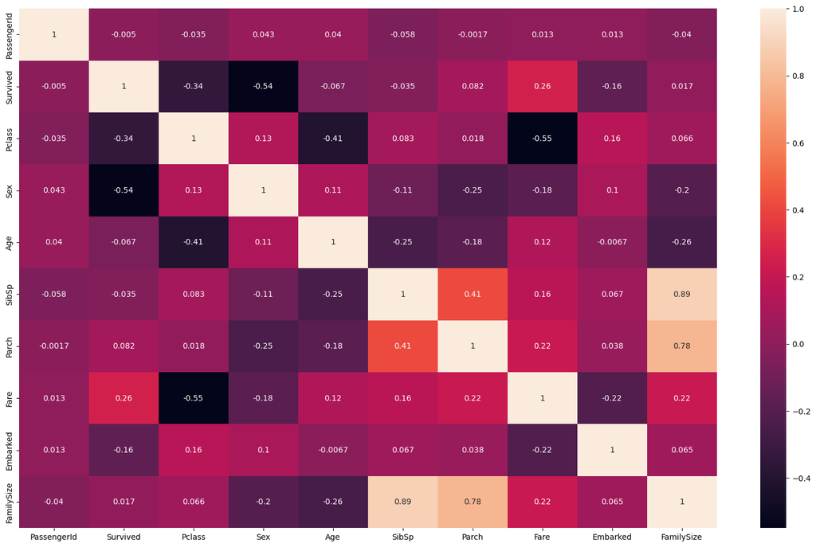

```python
plt.figure(figsize=(20,12))
sns.heatmap(df.corr(), annot=True)
```

## 9. Can we use violin plots to compare age distributions among passengers in different classes?

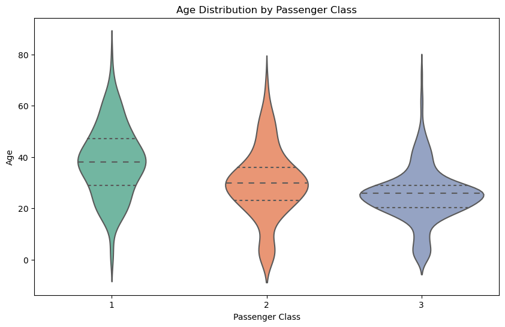

```python
plt.figure(figsize=(10, 6))
sns.violinplot(x='Pclass', y='Age', data=df, inner='quart', palette='Set2')
plt.xlabel('Passenger Class')
plt.ylabel('Age')
plt.title('Age Distribution by Passenger Class')
plt.show()
```

## 10. What are the survival rate trends by age group?

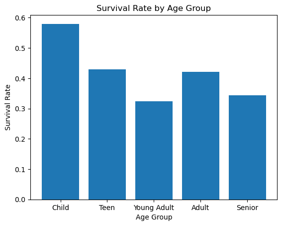

```python
bins = [0, 12, 18, 30, 50, 100]
labels = ['Child', 'Teen', 'Young Adult', 'Adult', 'Senior']
df['AgeGroup'] = pd.cut(df['Age'], bins=bins, labels=labels)

survival_rate_by_age = df.groupby('AgeGroup')['Survived'].mean()


plt.bar(survival_rate_by_age.index, survival_rate_by_age.values)
plt.xlabel('Age Group')
plt.ylabel('Survival Rate')
plt.title('Survival Rate by Age Group')
plt.show()
```

## 11. What machine learning algorithms are suitable for predicting survival?

```python
## Logistic Regression
## Decision Trees
## K-Nearest Neighbors (K-NN)
## Support Vector Machines (SVM)
from pandas.plotting import scatter_matrix
from sklearn.linear_model import LogisticRegression
from sklearn.tree import DecisionTreeClassifier
from sklearn.metrics import accuracy_score
from sklearn.metrics import confusion_matrix
from sklearn.model_selection import train_test_split
from sklearn.neighbors import KNeighborsClassifier
from sklearn.svm import SVC
from sklearn import preprocessing
```

```python
for col in df.select_dtypes(include=['object']).columns:

    print(f"{col}:{df[col].unique()}")
```

[output not shown]

[output cut: 520 more lines]

[output not shown]

```python
for col in df.select_dtypes(include=['object']).columns:

    label_encoder=preprocessing.LabelEncoder()
    label_encoder.fit(df[col].unique())

    df[col]=label_encoder.transform(df[col])

    print(f"(col):{df[col].unique()}")
```

[output not shown]

[output cut: 82 more lines]

```python
from sklearn import preprocessing
for col in df.select_dtypes(include=['category']).columns:

    print(f"{col}:{df[col].unique()}")
```

```
AgeGroup:['Young Adult', 'Adult', 'Senior', 'Child', 'Teen']
Categories (5, object): ['Child' < 'Teen' < 'Young Adult' < 'Adult' < 'Senior']
```

```python
for col in df.select_dtypes(include=['category']).columns:

    label_encoder=preprocessing.LabelEncoder()
    label_encoder.fit(df[col].unique())

    df[col]=label_encoder.transform(df[col])

    print(f"(col):{df[col].unique()}")
```

```
(col):[4 0 2 1 3]
```

```python
x = df.drop('Survived', axis=1)
y = df['Survived']
```

```python
x_train,x_test,y_train,y_test=train_test_split(x,y, test_size=0.25,random_state=42)
```

```python
dtree = DecisionTreeClassifier()
dtree.fit(x_train,y_train)
pre = dtree.predict(x_test)
accuracy_score(y_test,pre)
```

```
0.7982062780269058
```

```python
lm = LogisticRegression()
lm.fit(x_train,y_train)
pred = lm.predict(x_test)
accuracy_score(y_test,pred)
```

```
0.757847533632287
```

```python
s = SVC(kernel = 'linear')
s.fit(x_train,y_train)
pre = s.predict(x_test)
accuracy_score(y_test,pre)
```

```
0.7802690582959642
```

```python
knn = KNeighborsClassifier(n_neighbors=24)
knn.fit(x_train,y_train)
pre = knn.predict(x_test)
accuracy_score(y_test,pre)
```

```
0.6591928251121076
```

## 12. How do we handle imbalanced classes in the target variable (survived vs. not survived)?

Resampling Techniques:

##### Oversampling: Increase the number of instances in the minority class by duplicating or generating synthetic samples. Common oversampling techniques include Random Oversampling and Synthetic Minority Over-sampling Technique (SMOTE).

##### Undersampling: Reduce the number of instances in the majority class by randomly removing samples. Be cautious when undersampling, as it may result in loss of information.